# İstanbul - Beşiktaş İlçesi Seçim Sonuçları

secimler R paketi otomatik raporlama

2017-02-23

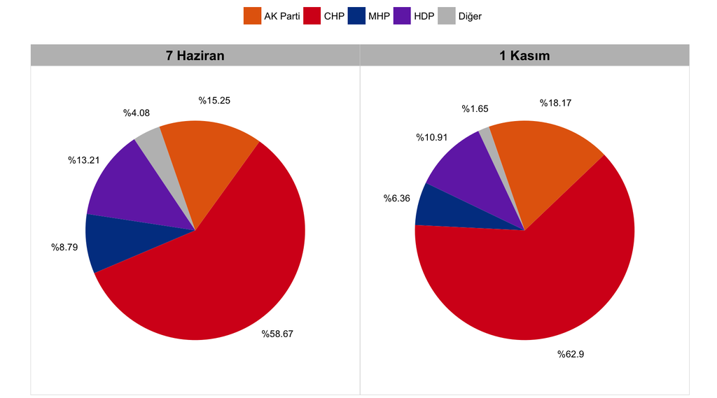

7 Haziran ve 1 Kasım 2015 genel seçimlerinin oy oranı bazında karşılaştırması.

# 7 Haziran 2015 Genel Seçimi Özet Bilgiler

Beşiktaş ilçesinde bu seçimde 23 mahalle ve toplamda 403 seçim sandığı bulunmaktadır. İlçe içerisinde toplam 146.261 kayıtlı seçmen bulunmaktadır. 125.771 seçmen oy kullanmış, geçerli oy sayısı ise 121.009 olmuştur. Seçime katılım oranı %85,99 olarak gerçekleşmiştir.

Toplam sonuçlarda AK Parti %15,25, CHP %58,67, MHP %8,79, HDP %13,21 ve diğer partiler ile bağımsızlar %4,08 oy oranına sahip olmuşlardır.

İlçe içerisinde sandık bazında partilere oy oranı dağılımı aşağıdaki grafikte gösterilmiştir. Kutu grafiğini yorumlamak için orta çizgi ortanca (medyan), alt ve üst çizgiler sırasıyla %25 ve %75lik dilimler ve noktalar da uç değerleri (outlier) göstermektedir. *(Örneğin bir partinin grafiğinin orta çizgisi %40 değerindeyse, sandıkların yarısında %40 ve üzeri, diğer yarısında ise %40 altı oy oranı var demektir.)*

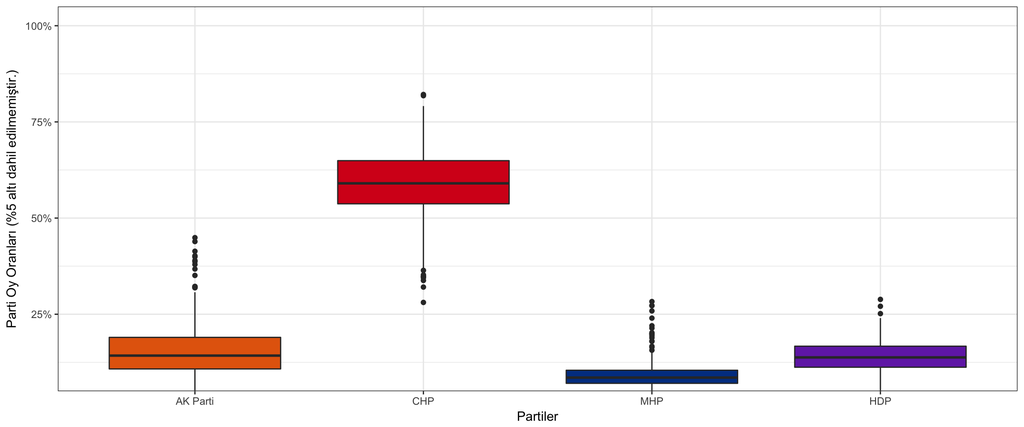

7 Haziran seçimlerinde partilerin seçim çevrelerinden aldıkları oy oranları kutu grafiği.

# 1 Kasım 2015 Genel Seçimi Özet Bilgiler

Beşiktaş ilçesinde bu seçimde 23 mahalle ve toplamda 402 seçim sandığı bulunmaktadır. İlçe içerisinde toplam 146.479 kayıtlı seçmen bulunmaktadır. 128.392 seçmen oy kullanmış, geçerli oy sayısı ise 127.470 olmuştur. Seçime katılım oranı %87,65 olarak gerçekleşmiştir.

Toplam sonuçlarda AK Parti %18,17, CHP %62,9, MHP %6,36, HDP %10,91 ve diğer partiler ile bağımsızlar %1,65 oy oranına sahip olmuşlardır.

İlçe içerisinde sandık bazında partilere oy oranı dağılımı aşağıdaki grafikte gösterilmiştir. Kutu grafiğini yorumlamak için orta çizgi ortanca (medyan), alt ve üst çizgiler sırasıyla %25 ve %75lik dilimler ve noktalar da uç değerleri (outlier) göstermektedir. *(Örneğin bir partinin grafiğinin orta çizgisi %40 değerindeyse, sandıkların yarısında %40 ve üzeri, diğer yarısında ise %40 altı oy oranı var demektir.)*

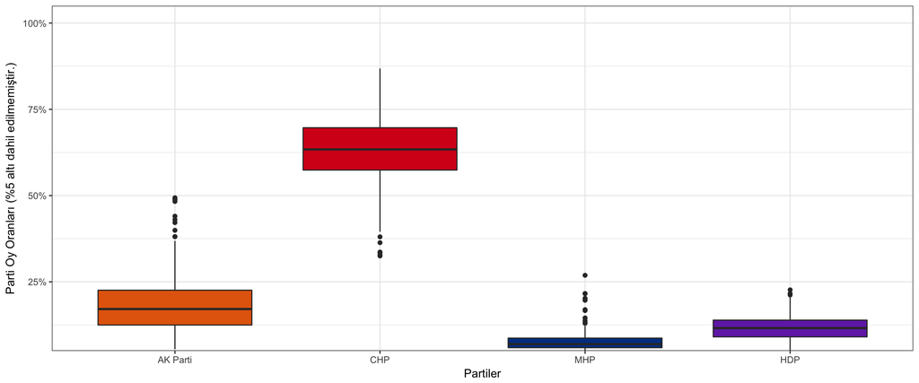

1 Kasım seçimlerinde partilerin seçim çevrelerinden aldıkları oy oranları kutu grafiği.

# Oy Kaymaları

7 Haziran ve 1 Kasım arasında partiler arasında oy kaymaları yaşanmıştır. Bu oy kaymaları seçim birimi bazındaki oy oranı değişimlerinin incelenmesi sonucu hesaplanmaktadır. Aşağıdaki tablolarda partiler arasındaki oy kaymaları verilmektedir. Tablolardaki oy kaymalarını incelerken lütfen aşağıdaki maddelere dikkat ediniz.

- Oy kaymaları satırdan sütuna okunmalıdır.
- Oy kaymaları puan bazındadır. Örneğin MHP’den AK Parti’ye %10 bir kayma; MHP’nin oylarının %10’unu değil, bütün oyların bir önceki seçimde MHP’ye ait olan %10luk kesimini belirtmektedir.
- Partilerin farklı sandıklarda oy oranları farklı şekillerde değiştiğinden iki partiden de birbirlerine oy kayması mümkün olabilir. Net oy kayması ayrı bir tabloda verilmiştir.
- Partiler arasında zincir olarak oy kayması yaşanmış olabilir. Örneğin MHP’den CHP’ye net oy kayması yaşanırken, CHP’den de AK Parti’ye net oy kayması yaşanmış olabilir.

Partiler arasındaki oy oranı kaymaları.

|  | AK Parti | CHP | MHP | HDP | Diğer |
| --- | --- | --- | --- | --- | --- |
| AK Parti | %0 | %0 | %0 | %0 | %0 |
| CHP | %0 | %0 | %0 | %0 | %0 |
| MHP | %0.98 | %1.45 | %0 | %0 | %0 |
| HDP | %0.93 | %1.37 | %0 | %0 | %0 |
| Diğer | %1 | %1.43 | %0 | %0 | %0 |

Partiler arasındaki net oy oranı kaymaları.

|  | AK Parti | CHP | MHP | HDP | Diğer |
| --- | --- | --- | --- | --- | --- |
| AK Parti | %0 | %0 | %0 | %0 | %0 |
| CHP | %0 | %0 | %0 | %0 | %0 |
| MHP | %0.98 | %1.45 | %0 | %0 | %0 |
| HDP | %0.93 | %1.37 | %0 | %0 | %0 |
| Diğer | %1 | %1.43 | %0 | %0 | %0 |

# İlçe Bazında Karşılaştırmalar

Aşağıdaki bilgilerde ilçe bazında özet grafikler bulunmaktadır. Bu grafiklerde her ilçenin toplam kayıtlı seçmen sayısı, geçerli oy sayısı, geçersiz oy sayısı ve barajı aşan partilerin (AK Parti, CHP, MHP ve HDP) oy oranları bulunmaktadır. İlçeler hakkında detaylı bilgi edinmek için ilçelerin kendi raporlarını inceleyebilirsiniz. *(Detaylı bilgi dökümanın sonunda yer almaktadır.)*

## Seçmen İstatistikleri

Kayıtlı seçmen sayısındaki değişim en yüksek oranda Gayrettepe (+%2.07) çevresinde (Mahalle) ve en düşük oranda Cıhannuma (-%1.41) çevresinde (Mahalle) görülmektedir. Seçime katılım oranında değişim ise en yüksek oranda Akat (+%2.22) çevresinde (Mahalle) ve en düşük oranda Sinanpaşa (-%0.04) çevresinde (Mahalle) görülmektedir.

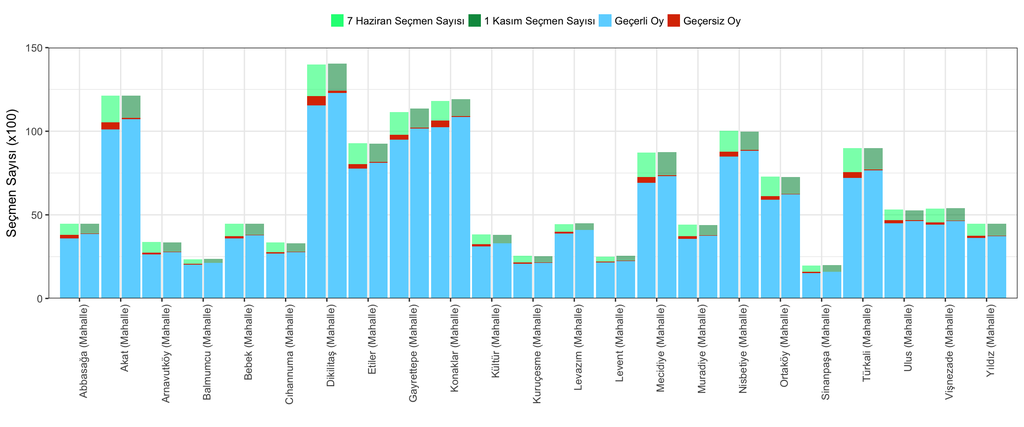

Seçim birimlerinin kayıtlı seçmen, geçerli ve geçersiz oy sayıları.

## Parti Oy Oranları

### AK Parti

AK Parti, 7 Haziran seçimlerinde İstanbul-Beşiktaş ilçesinin seçim çevreleri arasında en yüksek oy oranını Kuruçesme (Mahalle) (%25.02), en düşük oy oranını Nisbetiye (Mahalle) (%9.8) çevrelerinde görmüştür. 1 Kasım seçimlerinde ise en yüksek oy oranını Kuruçesme (Mahalle) (%29.06), en düşük oy oranını Nisbetiye (Mahalle) (%12.1) çevrelerinde görmüştür. Parti bu ilçedeki bütün çevrelerde oy oranlarını yükseltmiştir. Puan bazında en büyük yükseliş Kuruçesme (Mahalle) çevresinde (+%4.04) görülmektedir.

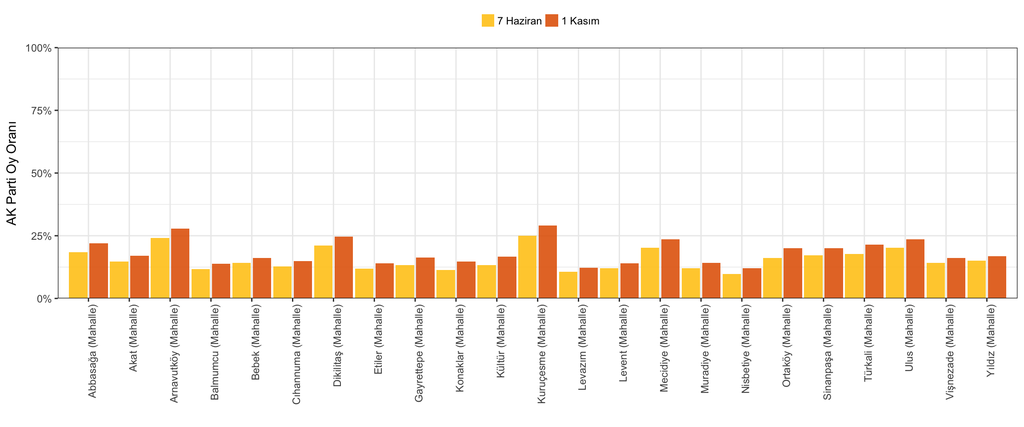

AK Parti’nin seçim birimlerinde aldığı oy oranları.

### CHP

CHP, 7 Haziran seçimlerinde İstanbul-Beşiktaş ilçesinin seçim çevreleri arasında en yüksek oy oranını Nisbetiye (Mahalle) (%66.71), en düşük oy oranını Abbasağa (Mahalle) (%49.71) çevrelerinde görmüştür. 1 Kasım seçimlerinde ise en yüksek oy oranını Nisbetiye (Mahalle) (%70.66), en düşük oy oranını Kuruçesme (Mahalle) (%53.21) çevrelerinde görmüştür. Parti bu ilçedeki bütün çevrelerde oy oranlarını yükseltmiştir. Puan bazında en büyük yükseliş Bebek (Mahalle) çevresinde (+%7.59) görülmektedir.

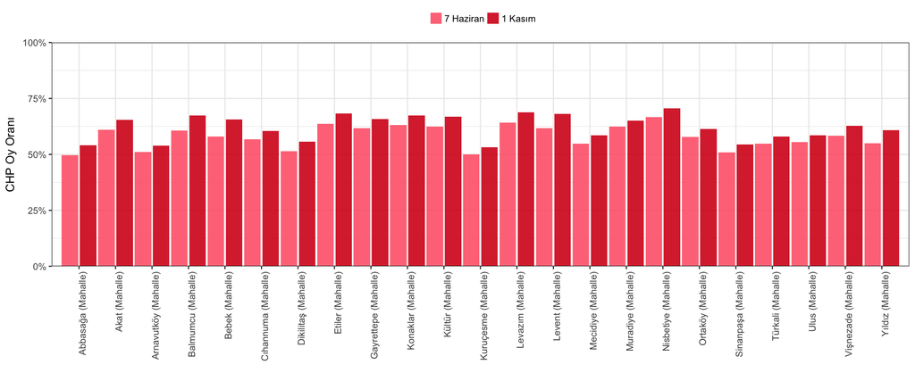

CHP’nin seçim birimlerinde aldığı oy oranları.

### MHP

MHP, 7 Haziran seçimlerinde İstanbul-Beşiktaş ilçesinin seçim çevreleri arasında en yüksek oy oranını Balmumcu (Mahalle) (%12.84), en düşük oy oranını Akat (Mahalle) (%6.86) çevrelerinde görmüştür. 1 Kasım seçimlerinde ise en yüksek oy oranını Konaklar (Mahalle) (%9.32), en düşük oy oranını Kuruçesme (Mahalle) (%4.16) çevrelerinde görmüştür. Parti bu ilçedeki hiçbir çevrede oy oranını yükseltememiştir. Puan bazında en büyük düşüş Balmumcu (Mahalle) çevresinde (-%4.02) görülmektedir.

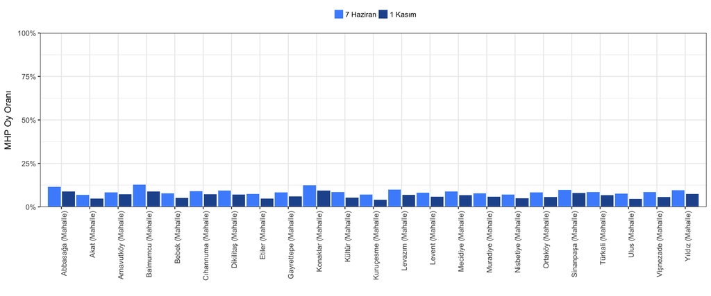

MHP’nin seçim birimlerinde aldığı oy oranları.

### HDP

HDP, 7 Haziran seçimlerinde İstanbul-Beşiktaş ilçesinin seçim çevreleri arasında en yüksek oy oranını Sinanpaşa (Mahalle) (%17.8), en düşük oy oranını Konaklar (Mahalle) (%8.89) çevrelerinde görmüştür. 1 Kasım seçimlerinde ise en yüksek oy oranını Sinanpaşa (Mahalle) (%15.71), en düşük oy oranını Konaklar (Mahalle) (%7.2) çevrelerinde görmüştür. Parti bu ilçedeki hiçbir çevrede oy oranını yükseltememiştir. Puan bazında en büyük düşüş Bebek (Mahalle) çevresinde (-%4.75) görülmektedir.

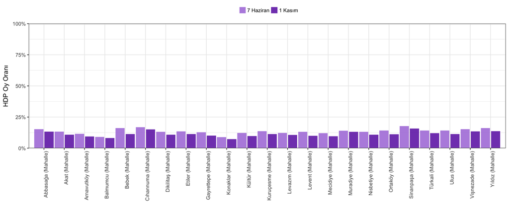

HDP’nin seçim birimlerinde aldığı oy oranları.

# Bilinmesi Gerekenler

- Bu döküman otomatik olarak oluşturulmuştur.
- Dökümanın amacı R ile veri analizi, görselleştirme ve otomatik raporlama konusunda bir eğitim örneği oluşturmaktır.
- Bu dökümanı oluşturmakta kullanılan veriler 7 Haziran ve 1 Kasım’a ait sandık bazında seçim sonucu verilerinden oluşmaktadır. Veriler TÜİK vasıtasıyla YSK kesin seçim sonuçlarından elde edilmiştir.
- Veriler veya hesaplamalarda yanlışlıklar olabilir. Veriler ve analizlerle ilgili herhangi bir sorumluluk kabul edilmemektedir.
- İlgili veri setleri ve analizlere `secimler` R paketi vasıtasıyla ulaşılabilir. Paket hala geliştirme aşamasında olup sürekli güncellenmektedir. https://github.com/berkorbay/secimler adresinden pakete ulaşılabilir ve yükleme talimatları görülebilir.
- Paketin yazarına (Berk Orbay) http://berkorbay.me adresinden ulaşabilirsiniz.